# Data manipulation in R

Examples of dplyr functions in R

First download the data and make sure you have dplyr installed

|  | name | genus | vore | order | conservation | sleep_total | sleep_rem | sleep_cycle | awake | brainwt | bodywt |
| --- | --- | --- | --- | --- | --- | --- | --- | --- | --- | --- | --- |
| 1 | Cheetah | Acinonyx | carni | Carnivora | lc | 12.1 | NA | NA | 11.9 | NA | 50.000 |
| 2 | Owl monkey | Aotus | omni | Primates | NA | 17.0 | 1.8 | NA | 7.0 | 0.01550 | 0.480 |
| 3 | Mountain beaver | Aplodontia | herbi | Rodentia | nt | 14.4 | 2.4 | NA | 9.6 | NA | 1.350 |
| 4 | Greater short-tailed shrew | Blarina | omni | Soricomorpha | lc | 14.9 | 2.3 | 0.1333333 | 9.1 | 0.00029 | 0.019 |
| 5 | Cow | Bos | herbi | Artiodactyla | domesticated | 4.0 | 0.7 | 0.6666667 | 20.0 | 0.42300 | 600.000 |
| 6 | Three-toed sloth | Bradypus | herbi | Pilosa | NA | 14.4 | 2.2 | 0.7666667 | 9.6 | NA | 3.850 |

# Key dplyr verbs

`select()` select columns  
`filter()` filter rows  
`arrange()` re-order or arrange rows  
`mutate()` create new columns  
`summarise()` summarise values  
`group_by()` allows for group operations in the “split-apply-combine” concept

# Select columns

```r
#select columns
sleepData <- dplyr::select(msleep, name, sleep_total)
head(sleepData)
```

|  | name | sleep_total |
| --- | --- | --- |
| 1 | Cheetah | 12.1 |
| 2 | Owl monkey | 17.0 |
| 3 | Mountain beaver | 14.4 |
| 4 | Greater short-tailed shrew | 14.9 |
| 5 | Cow | 4.0 |
| 6 | Three-toed sloth | 14.4 |

```r
#remove columns
head(dplyr::select(msleep, -name))
```

|  | genus | vore | order | conservation | sleep_total | sleep_rem | sleep_cycle | awake | brainwt | bodywt |
| --- | --- | --- | --- | --- | --- | --- | --- | --- | --- | --- |
| 1 | Acinonyx | carni | Carnivora | lc | 12.1 | NA | NA | 11.9 | NA | 50.000 |
| 2 | Aotus | omni | Primates | NA | 17.0 | 1.8 | NA | 7.0 | 0.01550 | 0.480 |
| 3 | Aplodontia | herbi | Rodentia | nt | 14.4 | 2.4 | NA | 9.6 | NA | 1.350 |
| 4 | Blarina | omni | Soricomorpha | lc | 14.9 | 2.3 | 0.1333333 | 9.1 | 0.00029 | 0.019 |
| 5 | Bos | herbi | Artiodactyla | domesticated | 4.0 | 0.7 | 0.6666667 | 20.0 | 0.42300 | 600.000 |
| 6 | Bradypus | herbi | Pilosa | NA | 14.4 | 2.2 | 0.7666667 | 9.6 | NA | 3.850 |

```r
#select by a range of columns :
head(dplyr::select(msleep, name:order))
```

|  | name | genus | vore | order |
| --- | --- | --- | --- | --- |
| 1 | Cheetah | Acinonyx | carni | Carnivora |
| 2 | Owl monkey | Aotus | omni | Primates |
| 3 | Mountain beaver | Aplodontia | herbi | Rodentia |
| 4 | Greater short-tailed shrew | Blarina | omni | Soricomorpha |
| 5 | Cow | Bos | herbi | Artiodactyla |
| 6 | Three-toed sloth | Bradypus | herbi | Pilosa |

try other commands like starts_with(“InsertCharacter”)

What about if the variable ends with a certain character?  
Contains a certain character? (`contains()`)  
Matches a regular expression? (`matches()`)  
Matches a numerical range? (`num_range()`)  
Is a variable in a character vector? (`one_of()`)  
All of them? (`everything()`)

e.g. head(dplyr::select(msleep, starts_with(“vo”))) will select columns starting with “vo”

# Reordering the selected columns

What if you want to easily reorder columns and you dont want to type all the column names?

Or rename column names?

```r
dplyr::select(msleep, vore, everything())
```

| vore | name | genus | order | conservation | sleep_total | sleep_rem | sleep_cycle | awake | brainwt | bodywt |
| --- | --- | --- | --- | --- | --- | --- | --- | --- | --- | --- |
| carni | Cheetah | Acinonyx | Carnivora | lc | 12.1 | NA | NA | 11.90 | NA | 50.000 |
| omni | Owl monkey | Aotus | Primates | NA | 17.0 | 1.8 | NA | 7.00 | 0.01550 | 0.480 |
| herbi | Mountain beaver | Aplodontia | Rodentia | nt | 14.4 | 2.4 | NA | 9.60 | NA | 1.350 |
| omni | Greater short-tailed shrew | Blarina | Soricomorpha | lc | 14.9 | 2.3 | 0.1333333 | 9.10 | 0.00029 | 0.019 |
| herbi | Cow | Bos | Artiodactyla | domesticated | 4.0 | 0.7 | 0.6666667 | 20.00 | 0.42300 | 600.000 |
| herbi | Three-toed sloth | Bradypus | Pilosa | NA | 14.4 | 2.2 | 0.7666667 | 9.60 | NA | 3.850 |
| carni | Northern fur seal | Callorhinus | Carnivora | vu | 8.7 | 1.4 | 0.3833333 | 15.30 | NA | 20.490 |
| NA | Vesper mouse | Calomys | Rodentia | NA | 7.0 | NA | NA | 17.00 | NA | 0.045 |
| carni | Dog | Canis | Carnivora | domesticated | 10.1 | 2.9 | 0.3333333 | 13.90 | 0.07000 | 14.000 |
| herbi | Roe deer | Capreolus | Artiodactyla | lc | 3.0 | NA | NA | 21.00 | 0.09820 | 14.800 |

[output cut: 73 more lines]

```r
rename(msleep, cvore = vore)
```

| name | genus | cvore | order | conservation | sleep_total | sleep_rem | sleep_cycle | awake | brainwt | bodywt |
| --- | --- | --- | --- | --- | --- | --- | --- | --- | --- | --- |
| Cheetah | Acinonyx | carni | Carnivora | lc | 12.1 | NA | NA | 11.90 | NA | 50.000 |
| Owl monkey | Aotus | omni | Primates | NA | 17.0 | 1.8 | NA | 7.00 | 0.01550 | 0.480 |
| Mountain beaver | Aplodontia | herbi | Rodentia | nt | 14.4 | 2.4 | NA | 9.60 | NA | 1.350 |
| Greater short-tailed shrew | Blarina | omni | Soricomorpha | lc | 14.9 | 2.3 | 0.1333333 | 9.10 | 0.00029 | 0.019 |
| Cow | Bos | herbi | Artiodactyla | domesticated | 4.0 | 0.7 | 0.6666667 | 20.00 | 0.42300 | 600.000 |
| Three-toed sloth | Bradypus | herbi | Pilosa | NA | 14.4 | 2.2 | 0.7666667 | 9.60 | NA | 3.850 |
| Northern fur seal | Callorhinus | carni | Carnivora | vu | 8.7 | 1.4 | 0.3833333 | 15.30 | NA | 20.490 |
| Vesper mouse | Calomys | NA | Rodentia | NA | 7.0 | NA | NA | 17.00 | NA | 0.045 |
| Dog | Canis | carni | Carnivora | domesticated | 10.1 | 2.9 | 0.3333333 | 13.90 | 0.07000 | 14.000 |
| Roe deer | Capreolus | herbi | Artiodactyla | lc | 3.0 | NA | NA | 21.00 | 0.09820 | 14.800 |

[output cut: 73 more lines]

# Selecting rows using filter

`filter` allows you extract rows

```r
filter(msleep, sleep_total >= 16)
```

| name | genus | vore | order | conservation | sleep_total | sleep_rem | sleep_cycle | awake | brainwt | bodywt |
| --- | --- | --- | --- | --- | --- | --- | --- | --- | --- | --- |
| Owl monkey | Aotus | omni | Primates | NA | 17.0 | 1.8 | NA | 7.0 | 0.01550 | 0.480 |
| Long-nosed armadillo | Dasypus | carni | Cingulata | lc | 17.4 | 3.1 | 0.3833333 | 6.6 | 0.01080 | 3.500 |
| North American Opossum | Didelphis | omni | Didelphimorphia | lc | 18.0 | 4.9 | 0.3333333 | 6.0 | 0.00630 | 1.700 |
| Big brown bat | Eptesicus | insecti | Chiroptera | lc | 19.7 | 3.9 | 0.1166667 | 4.3 | 0.00030 | 0.023 |
| Thick-tailed opposum | Lutreolina | carni | Didelphimorphia | lc | 19.4 | 6.6 | NA | 4.6 | NA | 0.370 |
| Little brown bat | Myotis | insecti | Chiroptera | NA | 19.9 | 2.0 | 0.2000000 | 4.1 | 0.00025 | 0.010 |
| Giant armadillo | Priodontes | insecti | Cingulata | en | 18.1 | 6.1 | NA | 5.9 | 0.08100 | 60.000 |
| Arctic ground squirrel | Spermophilus | herbi | Rodentia | lc | 16.6 | NA | NA | 7.4 | 0.00570 | 0.920 |

```r
filter(msleep, sleep_total >= 16, bodywt >=1)
```

| name | genus | vore | order | conservation | sleep_total | sleep_rem | sleep_cycle | awake | brainwt | bodywt |
| --- | --- | --- | --- | --- | --- | --- | --- | --- | --- | --- |
| Long-nosed armadillo | Dasypus | carni | Cingulata | lc | 17.4 | 3.1 | 0.3833333 | 6.6 | 0.0108 | 3.5 |
| North American Opossum | Didelphis | omni | Didelphimorphia | lc | 18.0 | 4.9 | 0.3333333 | 6.0 | 0.0063 | 1.7 |
| Giant armadillo | Priodontes | insecti | Cingulata | en | 18.1 | 6.1 | NA | 5.9 | 0.0810 | 60.0 |

```r
filter(msleep, vore %in% c("omni", "carni"))
```

| name | genus | vore | order | conservation | sleep_total | sleep_rem | sleep_cycle | awake | brainwt | bodywt |
| --- | --- | --- | --- | --- | --- | --- | --- | --- | --- | --- |
| Cheetah | Acinonyx | carni | Carnivora | lc | 12.1 | NA | NA | 11.90 | NA | 50.000 |
| Owl monkey | Aotus | omni | Primates | NA | 17.0 | 1.8 | NA | 7.00 | 0.01550 | 0.480 |
| Greater short-tailed shrew | Blarina | omni | Soricomorpha | lc | 14.9 | 2.3 | 0.1333333 | 9.10 | 0.00029 | 0.019 |
| Northern fur seal | Callorhinus | carni | Carnivora | vu | 8.7 | 1.4 | 0.3833333 | 15.30 | NA | 20.490 |
| Dog | Canis | carni | Carnivora | domesticated | 10.1 | 2.9 | 0.3333333 | 13.90 | 0.07000 | 14.000 |
| Grivet | Cercopithecus | omni | Primates | lc | 10.0 | 0.7 | NA | 14.00 | NA | 4.750 |
| Star-nosed mole | Condylura | omni | Soricomorpha | lc | 10.3 | 2.2 | NA | 13.70 | 0.00100 | 0.060 |
| African giant pouched rat | Cricetomys | omni | Rodentia | NA | 8.3 | 2.0 | NA | 15.70 | 0.00660 | 1.000 |
| Lesser short-tailed shrew | Cryptotis | omni | Soricomorpha | lc | 9.1 | 1.4 | 0.1500000 | 14.90 | 0.00014 | 0.005 |
| Long-nosed armadillo | Dasypus | carni | Cingulata | lc | 17.4 | 3.1 | 0.3833333 | 6.60 | 0.01080 | 3.500 |

[output cut: 29 more lines]

```r
filter(msleep, !conservation%in% c("lc", "domesticated"))
```

| name | genus | vore | order | conservation | sleep_total | sleep_rem | sleep_cycle | awake | brainwt | bodywt |
| --- | --- | --- | --- | --- | --- | --- | --- | --- | --- | --- |
| Owl monkey | Aotus | omni | Primates | NA | 17.0 | 1.8 | NA | 7.00 | 0.01550 | 0.480 |
| Mountain beaver | Aplodontia | herbi | Rodentia | nt | 14.4 | 2.4 | NA | 9.60 | NA | 1.350 |
| Three-toed sloth | Bradypus | herbi | Pilosa | NA | 14.4 | 2.2 | 0.7666667 | 9.60 | NA | 3.850 |
| Northern fur seal | Callorhinus | carni | Carnivora | vu | 8.7 | 1.4 | 0.3833333 | 15.30 | NA | 20.490 |
| Vesper mouse | Calomys | NA | Rodentia | NA | 7.0 | NA | NA | 17.00 | NA | 0.045 |
| African giant pouched rat | Cricetomys | omni | Rodentia | NA | 8.3 | 2.0 | NA | 15.70 | 0.00660 | 1.000 |
| Asian elephant | Elephas | herbi | Proboscidea | en | 3.9 | NA | NA | 20.10 | 4.60300 | 2547.000 |
| Western american chipmunk | Eutamias | herbi | Rodentia | NA | 14.9 | NA | NA | 9.10 | NA | 0.071 |
| Galago | Galago | omni | Primates | NA | 9.8 | 1.1 | 0.5500000 | 14.20 | 0.00500 | 0.200 |
| Giraffe | Giraffa | herbi | Artiodactyla | cd | 1.9 | 0.4 | NA | 22.10 | NA | 899.995 |

[output cut: 36 more lines]

```r
#removing duplicates
distinct(msleep)
```

| name | genus | vore | order | conservation | sleep_total | sleep_rem | sleep_cycle | awake | brainwt | bodywt |
| --- | --- | --- | --- | --- | --- | --- | --- | --- | --- | --- |
| Cheetah | Acinonyx | carni | Carnivora | lc | 12.1 | NA | NA | 11.90 | NA | 50.000 |
| Owl monkey | Aotus | omni | Primates | NA | 17.0 | 1.8 | NA | 7.00 | 0.01550 | 0.480 |
| Mountain beaver | Aplodontia | herbi | Rodentia | nt | 14.4 | 2.4 | NA | 9.60 | NA | 1.350 |
| Greater short-tailed shrew | Blarina | omni | Soricomorpha | lc | 14.9 | 2.3 | 0.1333333 | 9.10 | 0.00029 | 0.019 |
| Cow | Bos | herbi | Artiodactyla | domesticated | 4.0 | 0.7 | 0.6666667 | 20.00 | 0.42300 | 600.000 |
| Three-toed sloth | Bradypus | herbi | Pilosa | NA | 14.4 | 2.2 | 0.7666667 | 9.60 | NA | 3.850 |
| Northern fur seal | Callorhinus | carni | Carnivora | vu | 8.7 | 1.4 | 0.3833333 | 15.30 | NA | 20.490 |
| Vesper mouse | Calomys | NA | Rodentia | NA | 7.0 | NA | NA | 17.00 | NA | 0.045 |
| Dog | Canis | carni | Carnivora | domesticated | 10.1 | 2.9 | 0.3333333 | 13.90 | 0.07000 | 14.000 |
| Roe deer | Capreolus | herbi | Artiodactyla | lc | 3.0 | NA | NA | 21.00 | 0.09820 | 14.800 |

[output cut: 73 more lines]

```r
distinct(msleep, order, .keep_all= TRUE)
```

| name | genus | vore | order | conservation | sleep_total | sleep_rem | sleep_cycle | awake | brainwt | bodywt |
| --- | --- | --- | --- | --- | --- | --- | --- | --- | --- | --- |
| Cheetah | Acinonyx | carni | Carnivora | lc | 12.1 | NA | NA | 11.90 | NA | 50.000 |
| Owl monkey | Aotus | omni | Primates | NA | 17.0 | 1.8 | NA | 7.00 | 0.01550 | 0.480 |
| Mountain beaver | Aplodontia | herbi | Rodentia | nt | 14.4 | 2.4 | NA | 9.60 | NA | 1.350 |
| Greater short-tailed shrew | Blarina | omni | Soricomorpha | lc | 14.9 | 2.3 | 0.1333333 | 9.10 | 0.00029 | 0.019 |
| Cow | Bos | herbi | Artiodactyla | domesticated | 4.0 | 0.7 | 0.6666667 | 20.00 | 0.42300 | 600.000 |
| Three-toed sloth | Bradypus | herbi | Pilosa | NA | 14.4 | 2.2 | 0.7666667 | 9.60 | NA | 3.850 |
| Long-nosed armadillo | Dasypus | carni | Cingulata | lc | 17.4 | 3.1 | 0.3833333 | 6.60 | 0.01080 | 3.500 |
| Tree hyrax | Dendrohyrax | herbi | Hyracoidea | lc | 5.3 | 0.5 | NA | 18.70 | 0.01230 | 2.950 |
| North American Opossum | Didelphis | omni | Didelphimorphia | lc | 18.0 | 4.9 | 0.3333333 | 6.00 | 0.00630 | 1.700 |
| Asian elephant | Elephas | herbi | Proboscidea | en | 3.9 | NA | NA | 20.10 | 4.60300 | 2547.000 |

[output cut: 9 more lines]

Try with using `&` or `|` to select using multiple criteria

What about if want to select things not in that criteria?

What about selecting rows based on containing some value? hint: grepl  
filter(msleep, grepl(“Pr”,order))

What about selecting a random number of rows? (sample_n(msleep, 3))

Or a random percentage of rows? (sample_frac(msleep, 0.1))

# Piping

dplyr uses the pipe operator `%>%` which allows you to pipe output from one function to the input to another function. This means you can read functions from left to right rather than nesting functions, which can get very confusing!

Using the `.` means that you are referencing back to the data piped into the function

```r
#No piping
head(dplyr::select(msleep, name, sleep_total))
```

|  | name | sleep_total |
| --- | --- | --- |
| 1 | Cheetah | 12.1 |
| 2 | Owl monkey | 17.0 |
| 3 | Mountain beaver | 14.4 |
| 4 | Greater short-tailed shrew | 14.9 |
| 5 | Cow | 4.0 |
| 6 | Three-toed sloth | 14.4 |

```r
#Piping
msleep %>%
    dplyr::select(name, sleep_total) %>%
    head
```

|  | name | sleep_total |
| --- | --- | --- |
| 1 | Cheetah | 12.1 |
| 2 | Owl monkey | 17.0 |
| 3 | Mountain beaver | 14.4 |
| 4 | Greater short-tailed shrew | 14.9 |
| 5 | Cow | 4.0 |
| 6 | Three-toed sloth | 14.4 |

# More data handling options

What if you want to arrange by e.g. by date or by name?

```r
msleep %>% arrange(order) %>% head
```

|  | name | genus | vore | order | conservation | sleep_total | sleep_rem | sleep_cycle | awake | brainwt | bodywt |
| --- | --- | --- | --- | --- | --- | --- | --- | --- | --- | --- | --- |
| 1 | Tenrec | Tenrec | omni | Afrosoricida | NA | 15.6 | 2.3 | NA | 8.4 | 0.0026 | 0.900 |
| 2 | Cow | Bos | herbi | Artiodactyla | domesticated | 4.0 | 0.7 | 0.6666667 | 20.0 | 0.4230 | 600.000 |
| 3 | Roe deer | Capreolus | herbi | Artiodactyla | lc | 3.0 | NA | NA | 21.0 | 0.0982 | 14.800 |
| 4 | Goat | Capri | herbi | Artiodactyla | lc | 5.3 | 0.6 | NA | 18.7 | 0.1150 | 33.500 |
| 5 | Giraffe | Giraffa | herbi | Artiodactyla | cd | 1.9 | 0.4 | NA | 22.1 | NA | 899.995 |
| 6 | Sheep | Ovis | herbi | Artiodactyla | domesticated | 3.8 | 0.6 | NA | 20.2 | 0.1750 | 55.500 |

```r
#more complex
msleep %>%
    dplyr::select(name, order, sleep_total) %>%
    arrange(order, sleep_total) %>%
    head
```

|  | name | order | sleep_total |
| --- | --- | --- | --- |
| 1 | Tenrec | Afrosoricida | 15.6 |
| 2 | Giraffe | Artiodactyla | 1.9 |
| 3 | Roe deer | Artiodactyla | 3.0 |
| 4 | Sheep | Artiodactyla | 3.8 |
| 5 | Cow | Artiodactyla | 4.0 |
| 6 | Goat | Artiodactyla | 5.3 |

```r
msleep %>%
    dplyr::select(name, order, sleep_total) %>%
    arrange(order, sleep_total) %>%
    filter(sleep_total >= 16)
```

| name | order | sleep_total |
| --- | --- | --- |
| Big brown bat | Chiroptera | 19.7 |
| Little brown bat | Chiroptera | 19.9 |
| Long-nosed armadillo | Cingulata | 17.4 |
| Giant armadillo | Cingulata | 18.1 |
| North American Opossum | Didelphimorphia | 18.0 |
| Thick-tailed opposum | Didelphimorphia | 19.4 |
| Owl monkey | Primates | 17.0 |
| Arctic ground squirrel | Rodentia | 16.6 |

What if you want to arrange by multiple variables? arrange(msleep, vore, conservation)  
Or one ascending / one descending? arrange(msleep, desc(vore), conservation)

# Summarising

used to summarise data. Can involve base functions, own functions defined within the pipe / function or own functions defined outside the operation

```r
msleep%>%summarise(Mean_ST = mean(sleep_total), Med_ST = median(sleep_total))
```

| Mean_ST | Med_ST |
| --- | --- |
| 10.43373 | 10.1 |

```r
#summarise at - allows summary by partiuclar variables
msleep%>%summarise_at(vars(sleep_cycle, sleep_total), funs(n(), mean, median))
```

| sleep_cycle_n | sleep_total_n | sleep_cycle_mean | sleep_total_mean | sleep_cycle_median | sleep_total_median |
| --- | --- | --- | --- | --- | --- |
| 83 | 83 | NA | 10.43373 | NA | 10.1 |

```r
#play with other summarise variables
#e.g. including custom functions
summarise_at(msleep,vars(sleep_cycle,sleep_total), function(x) var(x - mean(x)))
```

| sleep_cycle | sleep_total |
| --- | --- |
| NA | 19.80568 |

What if you want to summarise all of the numeric variables? summarise_if(msleep, is.numeric, funs(n(),mean,median))

WHat if you want to summarise by factors? E.g check the number of levels / categories and count the missing observations: summarise_all(msleep[“vore”], funs(nlevels(.), nmiss=sum(is.na(.))))

# Add new columns - Mutate

The `mutate` function adds new columns to the dataframe

```r
msleep %>%
    mutate(rem_proportion = sleep_rem / sleep_total) %>%
    head
```

|  | name | genus | vore | order | conservation | sleep_total | sleep_rem | sleep_cycle | awake | brainwt | bodywt | rem_proportion |
| --- | --- | --- | --- | --- | --- | --- | --- | --- | --- | --- | --- | --- |
| 1 | Cheetah | Acinonyx | carni | Carnivora | lc | 12.1 | NA | NA | 11.9 | NA | 50.000 | NA |
| 2 | Owl monkey | Aotus | omni | Primates | NA | 17.0 | 1.8 | NA | 7.0 | 0.01550 | 0.480 | 0.1058824 |
| 3 | Mountain beaver | Aplodontia | herbi | Rodentia | nt | 14.4 | 2.4 | NA | 9.6 | NA | 1.350 | 0.1666667 |
| 4 | Greater short-tailed shrew | Blarina | omni | Soricomorpha | lc | 14.9 | 2.3 | 0.1333333 | 9.1 | 0.00029 | 0.019 | 0.1543624 |
| 5 | Cow | Bos | herbi | Artiodactyla | domesticated | 4.0 | 0.7 | 0.6666667 | 20.0 | 0.42300 | 600.000 | 0.1750000 |
| 6 | Three-toed sloth | Bradypus | herbi | Pilosa | NA | 14.4 | 2.2 | 0.7666667 | 9.6 | NA | 3.850 | 0.1527778 |

```r
#add more than one
msleep %>%
    mutate(rem_proportion = sleep_rem / sleep_total,
           bodywt_grams = bodywt * 1000) %>%
    head
```

|  | name | genus | vore | order | conservation | sleep_total | sleep_rem | sleep_cycle | awake | brainwt | bodywt | rem_proportion | bodywt_grams |
| --- | --- | --- | --- | --- | --- | --- | --- | --- | --- | --- | --- | --- | --- |
| 1 | Cheetah | Acinonyx | carni | Carnivora | lc | 12.1 | NA | NA | 11.9 | NA | 50.000 | NA | 50000 |
| 2 | Owl monkey | Aotus | omni | Primates | NA | 17.0 | 1.8 | NA | 7.0 | 0.01550 | 0.480 | 0.1058824 | 480 |
| 3 | Mountain beaver | Aplodontia | herbi | Rodentia | nt | 14.4 | 2.4 | NA | 9.6 | NA | 1.350 | 0.1666667 | 1350 |
| 4 | Greater short-tailed shrew | Blarina | omni | Soricomorpha | lc | 14.9 | 2.3 | 0.1333333 | 9.1 | 0.00029 | 0.019 | 0.1543624 | 19 |
| 5 | Cow | Bos | herbi | Artiodactyla | domesticated | 4.0 | 0.7 | 0.6666667 | 20.0 | 0.42300 | 600.000 | 0.1750000 | 600000 |
| 6 | Three-toed sloth | Bradypus | herbi | Pilosa | NA | 14.4 | 2.2 | 0.7666667 | 9.6 | NA | 3.850 | 0.1527778 | 3850 |

What if you want to apply a function to all the columns? (mutate_all(msleep, funs(“new” = .* 1000)))

Investigate the other functions of mutate using the tab

# Grouping and summarising

Piping comes into its when you want to group by a particular variable then summarise

```r
msleep %>%
    group_by(order) %>%
    summarise(avg_sleep = mean(sleep_total),
              min_sleep = min(sleep_total),
              max_sleep = max(sleep_total),
              total = n())
```

| order | avg_sleep | min_sleep | max_sleep | total |
| --- | --- | --- | --- | --- |
| Afrosoricida | 15.600000 | 15.6 | 15.6 | 1 |
| Artiodactyla | 4.516667 | 1.9 | 9.1 | 6 |
| Carnivora | 10.116667 | 3.5 | 15.8 | 12 |
| Cetacea | 4.500000 | 2.7 | 5.6 | 3 |
| Chiroptera | 19.800000 | 19.7 | 19.9 | 2 |
| Cingulata | 17.750000 | 17.4 | 18.1 | 2 |
| Didelphimorphia | 18.700000 | 18.0 | 19.4 | 2 |
| Diprotodontia | 12.400000 | 11.1 | 13.7 | 2 |
| Erinaceomorpha | 10.200000 | 10.1 | 10.3 | 2 |
| Hyracoidea | 5.666667 | 5.3 | 6.3 | 3 |

[output cut: 9 more lines]

```r
#how would you sort this by max sleep?
#What about if there are nas?
#OR
msleep %>% group_by(vore) %>%
  summarise_at(vars(sleep_cycle:sleep_total), funs(n(), mean(., na.rm = TRUE)))
```

| vore | sleep_cycle_n | sleep_rem_n | sleep_total_n | sleep_cycle_mean | sleep_rem_mean | sleep_total_mean |
| --- | --- | --- | --- | --- | --- | --- |
| carni | 19 | 19 | 19 | 0.3733333 | 2.290000 | 10.378947 |
| herbi | 32 | 32 | 32 | 0.4180556 | 1.366667 | 9.509375 |
| insecti | 5 | 5 | 5 | 0.1611111 | 3.525000 | 14.940000 |
| omni | 20 | 20 | 20 | 0.5924242 | 1.955556 | 10.925000 |
| NA | 7 | 7 | 7 | 0.1833333 | 1.880000 | 10.185714 |

# Do function

Function allows you to compute within groups

```r
#eg get the top two rows from "cd", "nt" and "en" categories of conservation
msleep %>% filter(conservation%in% c("cd", "nt","en")) %>% group_by(conservation) %>%
  do(head( . , 2))
```

| name | genus | vore | order | conservation | sleep_total | sleep_rem | sleep_cycle | awake | brainwt | bodywt |
| --- | --- | --- | --- | --- | --- | --- | --- | --- | --- | --- |
| Giraffe | Giraffa | herbi | Artiodactyla | cd | 1.9 | 0.4 | NA | 22.10 | NA | 899.995 |
| Pilot whale | Globicephalus | carni | Cetacea | cd | 2.7 | 0.1 | NA | 21.35 | NA | 800.000 |
| Asian elephant | Elephas | herbi | Proboscidea | en | 3.9 | NA | NA | 20.10 | 4.6030 | 2547.000 |
| Golden hamster | Mesocricetus | herbi | Rodentia | en | 14.3 | 3.1 | 0.2000000 | 9.70 | 0.0010 | 0.120 |
| Mountain beaver | Aplodontia | herbi | Rodentia | nt | 14.4 | 2.4 | NA | 9.60 | NA | 1.350 |
| House mouse | Mus | herbi | Rodentia | nt | 12.5 | 1.4 | 0.1833333 | 11.50 | 0.0004 | 0.022 |

```r
#Slice is used to select
msleep %>% dplyr::select(conservation,sleep_total) %>%
  filter(conservation %in% c("cd", "nt","en")) %>%
  group_by(conservation) %>%
  do(arrange(.,desc(sleep_total))) %>%  slice(3)
```

| conservation | sleep_total |
| --- | --- |
| en | 14.3 |
| nt | 12.5 |

```r
#slice means select the third row
```

# Join functions

This allows you to merge datasets together (like merge function)

1. Make a new dataframe by selecting the name columns of msleep, and creating a new dataframe.
2. Create new columns either from calculating new variables for sleep or sample from a distribution
3. Try out some of the join functions
4. Try removing some of the rows from one or both datasets (msleep and the new one) and playing with `left_join` and `right_join`

Check the help to see what other join functions there are

# Vertical combinations

Using `intersect` (rows that appear in both x and y)  
`union` (rows that appear in either or both x and y)  
`setdiff` (rows that appear in x but not y)

```r
#set up data for example
mtcars$model <- rownames(mtcars)
first <- mtcars[1:20, ]
second <- mtcars[10:32, ]
#intersect selects the unique rows common to both datasets
intersect(first, second)
```

| mpg | cyl | disp | hp | drat | wt | qsec | vs | am | gear | carb | model |
| --- | --- | --- | --- | --- | --- | --- | --- | --- | --- | --- | --- |
| 19.2 | 6 | 167.6 | 123 | 3.92 | 3.440 | 18.30 | 1 | 0 | 4 | 4 | Merc 280 |
| 17.8 | 6 | 167.6 | 123 | 3.92 | 3.440 | 18.90 | 1 | 0 | 4 | 4 | Merc 280C |
| 16.4 | 8 | 275.8 | 180 | 3.07 | 4.070 | 17.40 | 0 | 0 | 3 | 3 | Merc 450SE |
| 17.3 | 8 | 275.8 | 180 | 3.07 | 3.730 | 17.60 | 0 | 0 | 3 | 3 | Merc 450SL |
| 15.2 | 8 | 275.8 | 180 | 3.07 | 3.780 | 18.00 | 0 | 0 | 3 | 3 | Merc 450SLC |
| 10.4 | 8 | 472.0 | 205 | 2.93 | 5.250 | 17.98 | 0 | 0 | 3 | 4 | Cadillac Fleetwood |
| 10.4 | 8 | 460.0 | 215 | 3.00 | 5.424 | 17.82 | 0 | 0 | 3 | 4 | Lincoln Continental |
| 14.7 | 8 | 440.0 | 230 | 3.23 | 5.345 | 17.42 | 0 | 0 | 3 | 4 | Chrysler Imperial |
| 32.4 | 4 | 78.7 | 66 | 4.08 | 2.200 | 19.47 | 1 | 1 | 4 | 1 | Fiat 128 |
| 30.4 | 4 | 75.7 | 52 | 4.93 | 1.615 | 18.52 | 1 | 1 | 4 | 2 | Honda Civic |

[output cut: 1 more lines]

# Other useful functions

1. `bind_rows` and `bind_cols` work in the same way as `rbind` and `cbind`, and can be used within piping (nb so can `rbind` and `cbind`)
2. rowwise() allows you to apply a function across rows (useful for supporting complex operations to be applied to each row)
3. Percentiles eg quantile()

```r
msleep %>% group_by(order) %>%
  summarise(Pecentile_25=quantile(sleep_total, probs=0.25),
            Pecentile_50=quantile(sleep_total, probs=0.5),
            Pecentile_75=quantile(sleep_total, probs=0.75),
            Pecentile_99=quantile(sleep_total, probs=0.99))
```

| order | Pecentile_25 | Pecentile_50 | Pecentile_75 | Pecentile_99 |
| --- | --- | --- | --- | --- |
| Afrosoricida | 15.600 | 15.60 | 15.600 | 15.600 |
| Artiodactyla | 3.200 | 3.90 | 4.975 | 8.910 |
| Carnivora | 8.100 | 10.25 | 12.500 | 15.547 |
| Cetacea | 3.950 | 5.20 | 5.400 | 5.592 |
| Chiroptera | 19.750 | 19.80 | 19.850 | 19.898 |
| Cingulata | 17.575 | 17.75 | 17.925 | 18.093 |
| Didelphimorphia | 18.350 | 18.70 | 19.050 | 19.386 |
| Diprotodontia | 11.750 | 12.40 | 13.050 | 13.674 |
| Erinaceomorpha | 10.150 | 10.20 | 10.250 | 10.298 |
| Hyracoidea | 5.350 | 5.40 | 5.850 | 6.282 |

[output cut: 9 more lines]

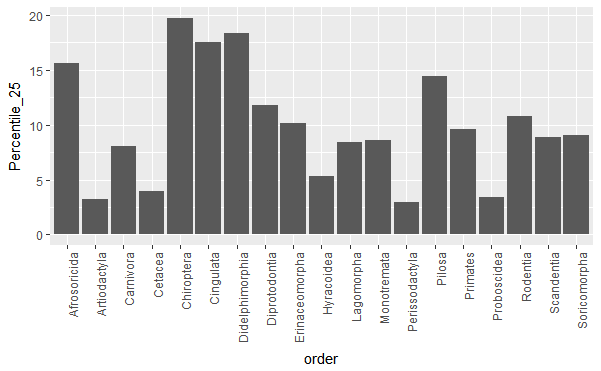

```r
#throw in a plot
msleep %>% group_by(order) %>%
  summarise(Percentile_25=quantile(sleep_total, probs=0.25),
            Percentile_50=quantile(sleep_total, probs=0.5),
            Percentile_75=quantile(sleep_total, probs=0.75),
            Percentile_99=quantile(sleep_total, probs=0.99)) %>%
  ggplot(.)+geom_bar(aes(order, Percentile_25), stat = "identity")+theme(axis.text.x = element_text(angle = 90, hjust = 1))
```

# Automate model building

Using `do` function you can automate model building

```r
by_cyl <- group_by(mtcars, cyl)
models <- by_cyl %>% do(mod = lm(mpg ~ disp, data = .))
summarise(models, rsq = summary(mod)$r.squared)
```

| rsq |
| --- |
| 0.64840514 |
| 0.01062604 |
| 0.27015777 |

```r
models %>% do(data.frame(
  var = names(coef(.$mod)),
  coef(summary(.$mod)))
)
```

|  | var | Estimate | Std..Error | t.value | Pr...t.. |
| --- | --- | --- | --- | --- | --- |
| 1 | (Intercept) | 40.871955322 | 3.589605400 | 11.3861973 | 1.202715e-06 |
| 2 | disp | -0.135141815 | 0.033171608 | -4.0740206 | 2.782827e-03 |
| 3 | (Intercept) | 19.081987419 | 2.913992892 | 6.5483988 | 1.243968e-03 |
| 4 | disp | 0.003605119 | 0.015557115 | 0.2317344 | 8.259297e-01 |
| 5 | (Intercept) | 22.032798914 | 3.345241115 | 6.5863112 | 2.588765e-05 |
| 6 | disp | -0.019634095 | 0.009315926 | -2.1075838 | 5.677488e-02 |

```r
NA
```

# If family of functions

These come into play with `mutate`, `summarise` etc when a condition is met

e.g. `select_if`, `summarise_if`, `mutate_if`, `na_if` (this converts all given values to na, eg if you want to find “” or have an indicator value as a null)

[output not shown]

[output cut: 73 more lines]